# StatComp Project 2: Scottish weather

Axel Eichelmann (s2030757, axeleichelmann)

# Scottish Weather Data

The data set `ghcnd_values` contain daily measurements of weather variables (such as precipitation, temperature, etc.) from the following 8 weather stations in Scotland

| ID | Name | Latitude | Longitude | Elevation |
| --- | --- | --- | --- | --- |
| UKE00105874 | BRAEMAR | 57.0058 | -3.3967 | 339 |
| UKE00105875 | BALMORAL | 57.0367 | -3.2200 | 283 |
| UKE00105884 | ARDTALNAIG | 56.5289 | -4.1108 | 130 |
| UKE00105885 | FASKALLY | 56.7181 | -3.7689 | 94 |
| UKE00105886 | LEUCHARS | 56.3767 | -2.8617 | 10 |
| UKE00105887 | PENICUIK | 55.8239 | -3.2258 | 185 |
| UKE00105888 | EDINBURGH: ROYAL BOTANIC GARDE | 55.9667 | -3.2100 | 26 |
| UKE00105930 | BENMORE: YOUNGER BOTANIC GARDE | 56.0281 | -4.9858 | 12 |

from the $1^{st}$ of January 1960 to the $31^{st}$ of December 2018 in this section, we will seek to gain an understanding of how the probability of rainfall, as well as precipitation measurements vary across the year.

### Seasonal Variance in Precipitation Amount

The figure below shows daily precipitation data from the year 1985 for each station. We also include the temperature data to show that the seasonal effects on precipitation are much less clear than their effects on temperature.

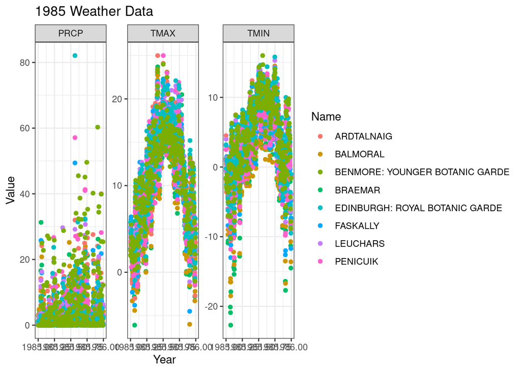

As we can see, there is an obvious increase in Maximum and Minimum temperature during the summer months. In contrast, there is no clear trend for the precipitation data.

In order to get a better understanding of the behaviour of rainfall throughout the year, we will carry out a Monte-Carlo premutation test on the hypothesis:
$$H_0: \text{The rainfall
distribution is the same in winter as in summer} \\
H_1: \text{The winter and summer distributions have different expected
values}$$

Here we will let the test statistic be $T = |\text{Winter Average Rainfall} - \text{Summer Average Rainfall}|$. Under the null hypothesis, the joint sample of Summer plus Winter rainfall would be a set of exchangeable variables, thus any random permutation of this set would have the same distribution as the original summer and winter rainfall data sets themselves. Our original data set gives the mean rainfall in summer and winter across the 8 stations, with corresponding test statistic values as:

| Station ID | Avg. Summer Rainfall | Avg. Winter Rainfall | T-Value |
| --- | --- | --- | --- |
| UKE00105874 | 2.089790 | 2.878589 | 0.7887997 |
| UKE00105875 | 1.994370 | 2.601891 | 0.6075213 |
| UKE00105884 | 2.668042 | 4.679448 | 2.0114061 |
| UKE00105885 | 2.130559 | 2.899627 | 0.7690686 |
| UKE00105886 | 1.809706 | 1.931070 | 0.1213640 |
| UKE00105887 | 2.326199 | 2.751264 | 0.4250654 |
| UKE00105888 | 1.844564 | 1.869338 | 0.0247740 |
| UKE00105930 | 4.995383 | 8.353198 | 3.3578143 |

| Station Name | Station ID | p-value |
| --- | --- | --- |
| BRAEMAR | UKE00105874 | 0 |
| BALMORAL | UKE00105875 | 0 |
| ARDTALNAIG | UKE00105884 | 0 |
| FASKALLY | UKE00105885 | 0 |
| LEUCHARS | UKE00105886 | 0.0337 |
| PENICUIK | UKE00105887 | 0 |
| EDINBURGH: ROYAL BOTANIC GARDE | UKE00105888 | 0.6585 |
| BENMORE: YOUNGER BOTANIC GARDE | UKE00105930 | 0 |

### Seasonal Variance in Probability of Rainfall

In order to get a better understanding of how the probability of rainfall changes throughout the year, we will carry out another Monte-Carlo Permutation test, this time on the hypotheses
$$H_0: \text{The daily probability of rainfall is
the same in winter as in the summer} \\
H_1: \text{The daily probability of rainfall is different in winter and
in summer}$$
This time, we will use $T = |\text{winter empirical nonzero proportion$−$summer empirical nonzero proportion}|$ as the test statistic. The original data set gives the T-values for each station as:

| Station ID | Summer Rainfall Probability | Winter Rainfall Probability | T-Value |
| --- | --- | --- | --- |
| UKE00105874 | 0.3065366 | 0.3583567 | 0.0518201 |
| UKE00105875 | 0.2856106 | 0.3279466 | 0.0423360 |
| UKE00105884 | 0.2981774 | 0.3463426 | 0.0481652 |
| UKE00105885 | 0.2898350 | 0.3387321 | 0.0488971 |
| UKE00105886 | 0.2545244 | 0.2791183 | 0.0245940 |
| UKE00105887 | 0.2887256 | 0.3286598 | 0.0399342 |
| UKE00105888 | 0.2507553 | 0.2815804 | 0.0308252 |
| UKE00105930 | 0.3289275 | 0.3749528 | 0.0460253 |

| Station Name | Station ID | p-value |
| --- | --- | --- |
| BRAEMAR | UKE00105874 | 0 |
| BALMORAL | UKE00105875 | 0 |
| ARDTALNAIG | UKE00105884 | 0 |
| FASKALLY | UKE00105885 | 0 |
| LEUCHARS | UKE00105886 | 0 |
| PENICUIK | UKE00105887 | 0 |
| EDINBURGH: ROYAL BOTANIC GARDE | UKE00105888 | 0 |
| BENMORE: YOUNGER BOTANIC GARDE | UKE00105930 | 0 |

# Spatial Weather Prediction

Below is a plot of the average daily precipitation in each month, averaged out across all the year in our `ghcnd_values` data set.

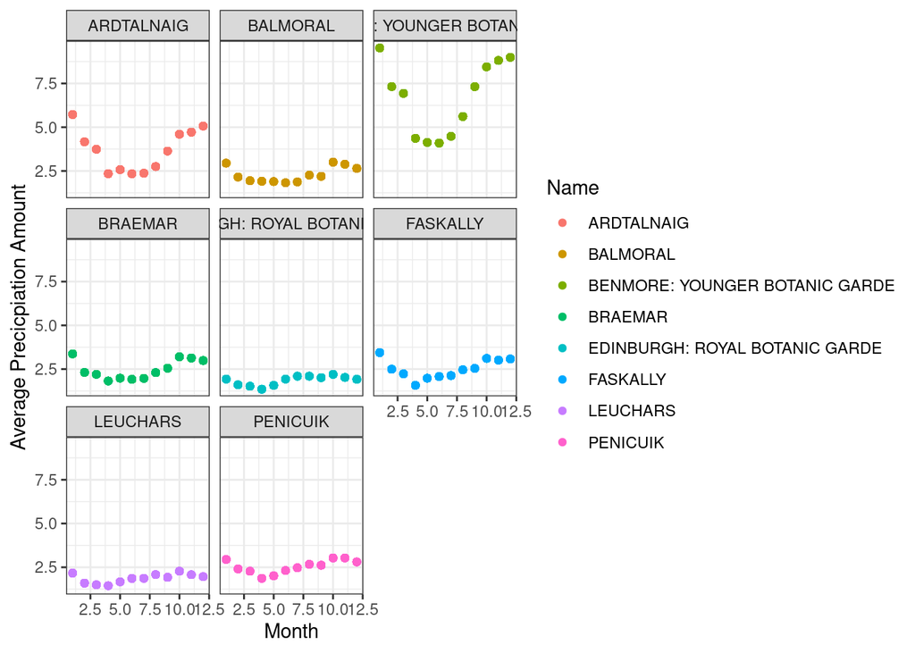

This graph shows that at each location the monthly average precipitation follows a wave-like curve with peaks in January and October meaning we can model this easily using a $\cos$ wave. We also see that for stations which are further west such as Ardtalnaig and Benmore, the amplitude of this curve is greater since there is a higher average rainfall in the winter months compared to the other stations. Now, using the `lm` function we can estimate a multiple linear regression model for the monthly average rainfall as
$$y_i =
25.84-2.205\theta_{i1}-0.5493\theta_{i2}+8.941\times
10^{-4}\theta_{i3}+0.8333\theta{i4}+e_i$$
where for each $(\theta_{i1},\theta_{i2},\theta_{i3},\theta_{i4}) = (x_{i1},x_{i2},x_{i3},\cos(\frac{365x_{i4}}{300}2\pi)$ and $x_{i1},x_{i2},x_{i3},x_{i4}$ are the values of the longitude, latitude, elevation, and DecYear given in the `ghcnd_values` data frame respectively, and $e_i$ is the random error component. Here I chose to model the seasonal variation using $\cos(\frac{365x_{i4}}{300}2\pi)$ since the peaks of this function are in January and October, thus follows the seasonal trend from the above figure fairly accurately. The figure below plots the prediciton of this model on the data subset of `ghcnd_values` from the year 1987 (chosen randomly for the sake of testing the model).

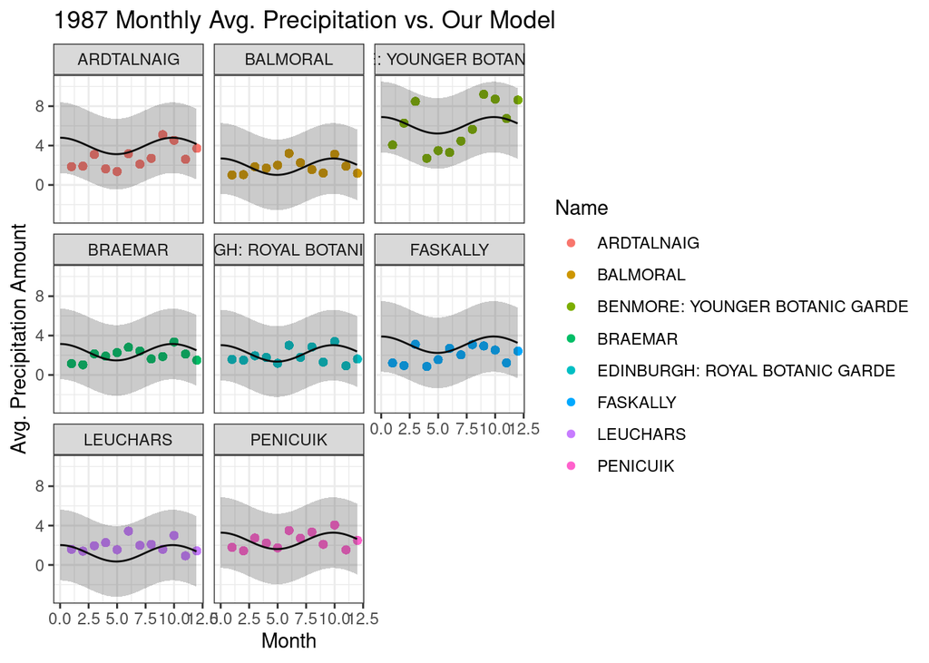

We can also plot the residuals of our model for this year.

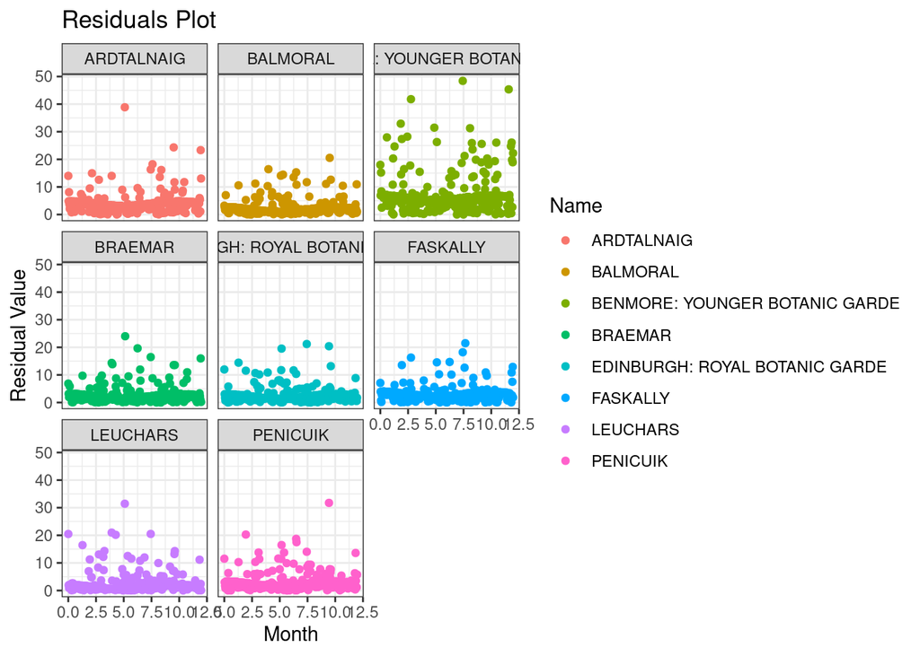

As we can see, in this example our model work pretty well since all of the points in the data set lie within the 95% prediction interval of our model, and the Residuals plot shows that most of the fitted values lie within $10mm$ of the true precipitation value on a given day in this year.

### Assesment of our Model

We now want to see whether the model is equally good at predicting the rainfall for each station, and whether the prediction accuracy is the same across the year. Carrying out a cross-validation test on each station we get scores for each station as:

| Station ID | Station Name | Average Squared Error Score | Average Dawid-Sebastiani Score |
| --- | --- | --- | --- |
| UKE00105874 | BRAEMAR | 22.80353 | 17081.11 |
| UKE00105875 | BALMORAL | 20.56109 | 16878.19 |
| UKE00105884 | ARDTALNAIG | 42.77531 | 64036.09 |
| UKE00105885 | FASKALLY | 22.96315 | 38031.08 |
| UKE00105886 | LEUCHARS | 18.35987 | 21605.78 |
| UKE00105887 | PENICUIK | 25.44270 | 18796.65 |
| UKE00105888 | EDINBURGH: ROYAL BOTANIC GARDE | 17.18348 | 14502.72 |
| UKE00105930 | BENMORE: YOUNGER BOTANIC GARDE | 106.05406 | 41510.11 |

As we can see from these results, our model is definitely better at predicting results for certain stations compared to others. In particular, it does a poor job at making predictions for Benmore and Ardtalnaig, possibly due to the fact that these are the stations whose precipitation values vary the most across the year. The lowest squared-error and Dawid-Sebastiani score here corresponds to the Edinburgh Station. This coincides with the fact that Edinburgh did not show evidence for having different precipitation variation in the different seasons (as calculated in the permutation test earlier). We can theorise from this information that our model may not account very well for seasonal variation in precipitation.

Now, we can also carry out a cross-validation test to see whether the model makes better predictions for certain months compared to others.

| Month | Average Squared Error Score | Average Dawid-Sebastiani Score |
| --- | --- | --- |
| 1 | 53.71997 | 69197.44 |
| 2 | 35.70544 | 45975.36 |
| 3 | 34.00025 | 43531.06 |
| 4 | 23.24835 | 29518.05 |
| 5 | 22.33497 | 27947.90 |
| 6 | 26.03411 | 32652.12 |
| 7 | 27.67017 | 35645.08 |
| 8 | 37.03876 | 48516.40 |
| 9 | 41.76377 | 52339.86 |
| 10 | 51.36715 | 66177.40 |
| 11 | 48.89556 | 64140.86 |
| 12 | 51.79060 | 65563.97 |

As we see from these results, our model makes better predictions for the summer months than it does for the winter months as both the squared-error and Dawid-Sebastiani scores are higher in winter than in summer. I believe this is because our model may not account for the greater variation of the precipitation in the winter months, hence the actual precipitation values in these months lie further for the model’s expected value than it does in the summer months. This also backs up our theory that the model does not account for seasonal variation in precipitation very well.

# Code appendix

## Function definitions

```r
# Axel Eichelmann (s2030757, axeleichelmann)

# Place your function definitions that may be needed in analysis.R and report.Rmd
# in this file, including documentation.
# You can also include any needed library() calls here


library(shiny)
library(tidyverse)
library(dplyr)
library(StatCompLab)

data(ghcnd_stations, package = "StatCompLab")
data(ghcnd_values, package = "StatCompLab")

#Function which computes the test-stat for each station, w\ an option to randomize the season labels
test_stat <- function(randomise = FALSE) {
  PRCP_data <- mutate(ghcnd_values, Season = if_else(Month %in% c(1,2,3,10,11,12), 'Winter', 'Summer')) %>%
    filter(Element == "PRCP") %>% group_by(ID) %>% select(ID, Value, Season)
  if (randomise == TRUE) {
    for (i in ghcnd_stations$ID) {
      var <- PRCP_data$Season[PRCP_data$ID==i]
      PRCP_data$Season[PRCP_data$ID==i] <- sample(var, size = length(PRCP_data$Season[PRCP_data$ID == i]))
    }
  }
  Avg_Summer_Rf <- PRCP_data %>% summarize(Summer_rf = mean(Value[Season=='Summer']))
  Avg_Winter_Rf <- PRCP_data %>% summarize(Winter_rf = mean(Value[Season=='Winter']))
  table <- Avg_Summer_Rf %>% right_join(Avg_Winter_Rf, by = "ID")
  table <- mutate(table, t_value = abs(Summer_rf-Winter_rf))
  colnames(table) <- c("Station ID", "Avg. Summer Rf", "Avg. Winter Rf", "T-Value")
  table
}

# Create function which calculates the empirical non-zero proportion of rainfall in Winter and Summer
prcp_prob <- function(randomise = FALSE){
  PRCP_data <- mutate(ghcnd_values, Season = if_else(Month %in% c(1,2,3,10,11,12),'Winter','Summer')) %>%
    filter(Element == "PRCP") %>% group_by(ID) %>%
    mutate(Rainfall = if_else(Value == 0, 0, 1)) %>% select(ID, Rainfall, Season)
  if (randomise== TRUE){
    for (i in ghcnd_stations$ID) {
      var <- PRCP_data$Season[PRCP_data$ID==i]
      PRCP_data$Season[PRCP_data$ID==i] <- sample(var, size = length(PRCP_data$Season[PRCP_data$ID == i]))
    }
  }

  Summer_prob <- PRCP_data %>% summarise(summer_prob = sum(Rainfall[Season == 'Summer'])/length(Rainfall))
  Winter_prob <- PRCP_data %>% summarise(winter_prob = sum(Rainfall[Season == 'Winter'])/length(Rainfall))
  table <- right_join(Summer_prob, Winter_prob, by = "ID")
  table <- mutate(table, t_value = abs(summer_prob-winter_prob))
  colnames(table) <- c("Station ID", "Summer Rf Prob", "Winter Rf Prob", "T-Value")
  table
}

#version of data set with monthly average precipitation values in each year
monthly_avg_data <- ghcnd_values %>% filter(Element == "PRCP") %>% group_by(ID,Year,Month) %>%
                    mutate(monthly_avg = mean(Value)) %>% right_join(ghcnd_stations, by = "ID")

# average monthly precipitation across all years
graph_monthly_avg <- ghcnd_values %>% filter(Element == "PRCP") %>% group_by(ID, Month) %>%
                     mutate(monthly_mu = mean(Value)) %>% left_join(ghcnd_stations, by = "ID")

model <- lm(monthly_avg ~ Longitude+Latitude+Elevation + cos((DecYear-Year)*2*pi*365/300), data = monthly_avg_data)


# code for the station Cross Validation
complete_ghcnd <- ghcnd_values %>% filter(Element == "PRCP") %>%
                  right_join(ghcnd_stations, by = "ID") %>% group_by(ID)

ID_set <- ghcnd_stations$ID[-1]
cv_model_data <- complete_ghcnd %>% filter(ID %in% ID_set)
CV_model <- lm(Value ~ Longitude + Latitude + cos((DecYear-Year)*2*pi*365/300), data = cv_model_data)
predict_data <- complete_ghcnd %>% filter(ID == ghcnd_stations$ID[1])
pred_values <- data.frame(predict_data, pred = predict(CV_model, predict_data),
                                        pred_sd = predict(CV_model, predict_data, se.fit = TRUE))

for (i in 2:8){
  ID_set <- ghcnd_stations$ID[-i]
  cv_model_data <- complete_ghcnd %>% filter(ID %in% ID_set)
  CV_model <- lm(Value ~ Longitude + Latitude + cos((DecYear-Year)*2*pi*365/300), data = cv_model_data)
  predict_data <- complete_ghcnd %>% filter(ID == ghcnd_stations$ID[i])
  pred_values <- rbind(pred_values, data.frame(predict_data, pred = predict(CV_model, predict_data),
                                               pred_sd = predict(CV_model, predict_data, se.fit = TRUE)))
}

# code for the month cross validation
month_ghcnd <- ghcnd_values %>% filter(Element == "PRCP") %>%
  right_join(ghcnd_stations, by = "ID") %>% group_by(Month)

month_set <- c(1,2,3,4,5,6,7,8,9,10,11,12)[-1]
cv_model_data <- month_ghcnd %>% filter(Month %in% month_set)
CV_model <- lm(Value ~ Longitude + Latitude + cos((DecYear-Year)*2*pi*365/300), data = cv_model_data)
predict_data <- month_ghcnd %>% filter(Month == 1)
pred_month_values <- data.frame(predict_data, pred = predict(CV_model, predict_data),
                          pred_sd = predict(CV_model, predict_data, se.fit = TRUE))

for (i in 2:12){
  month_set <- c(1,2,3,4,5,6,7,8,9,10,11,12)[-i]
  cv_model_data <- month_ghcnd %>% filter(Month %in% month_set)
  CV_model <- lm(Value ~ Longitude + Latitude + cos((DecYear-Year)*2*pi*365/300), data = cv_model_data)
  predict_data <- month_ghcnd %>% filter(Month == i)
  pred_month_values <- rbind(pred_month_values,
                             data.frame(predict_data, pred = predict(CV_model, predict_data),
                                        pred_sd = predict(CV_model, predict_data, se.fit = TRUE)))
}
```

## Analysis code

```r
# Axel Eichelmann (s2030757, axeleichelmann)
# Place analysis code that may take too long to run every time the report.Rmd
# document is run.
# Run the code in this file with
#   source("analysis.R")
# in a fresh R session to ensure consistency of the results.

# Load function definitions
source("functions.R")


# A code=readlines() code chunk in the report appendix will include the code
# in the report, without running it.
#
# You can place long-running analysis code in this file,
# and save results using
#   saveRDS(object, file = "data/object.rds")
# When the results are needed in the report.Rmd file, use
#   object <- readRDS(file = "data/object.rds")
# Make sure to use different filenames for each object, such as the object
# name itself.
#
# Remember to rerun this code to save new results when you change the code.
#
# The .gitignore file has been setup so that it ignores .rds files in the data/
# folder, so that you don't accidentally make git handle large binary data files.


#calculate the p-values of mean rainfall for each station
p <- 100
p_vals <- c(0,0,0,0,0,0,0,0)
orig_t <- as.vector(test_stat()$'T-Value')
for (i in 1:p){
  p_test_stat <- as.vector(test_stat(randomise = TRUE)$'T-Value')
  diff <- p_test_stat-orig_t
  for (i in 1:8){
    if (diff[i]>0){
      p_vals[i] = p_vals[i]+1
    }
  }
}
p_vals_mean <- p_vals/p
saveRDS(p_vals_mean, file = "data/p_vals_mean.rds")


#calculate the p-values of rainfall probability for each station
p <- 10000
p_vals_prob <- c(0,0,0,0,0,0,0,0)
orig_t <- as.vector(prcp_prob()$'T-Value')
for (i in 1:p){
  p_test_stat <- as.vector(prcp_prob(randomise = TRUE)$'T-Value')
  diff <- p_test_stat-orig_t
  for (i in 1:8){
    if (diff[i]>0){
      p_vals[i] = p_vals[i]+1
    }
  }
}
p_vals_prob <- p_vals_prob/p
saveRDS(p_vals_prob, file = "data/p_vals_prob.rds")
```